# Hodowla zwierzątek

Domink Ambroziak, Anna Dymowska, Adam Król

26 października 2016

# Założenia strategii

#### 1. Gdy tylko jesteśmy w stanie wymienić tańsze zwierzęta na droższe - wymieniamy.

#### 2. W drugą stronę wyminiamy tylko wtedy, gdy jest to ruch kończący grę.

#### 3. Dużego psa kupujemy przed krową.

#### 4. Nie kupujemy małych psów, ponieważ nadmiar królików zazwyczaj jest wymieniany na droższe zwierze.

# Kod

```r
zwierzeta<-data.frame(krolik=c(0,1,60),owca=c(0,6,24),swinia=c(0,12,20),krowa=c(0,36,12),duzy.pies=c(0,36,2),kon=c(0,72,6),maly.pies=c(0,6,4),row.names=c("liczba","krolikowartosc","wstadzie"))
```

W ramce danych “zwierzeta” przechowujemy informacje o ilości posiadanych przez nas zwierząt, ich wartości (w królikach) i liczbie zwierząt pozostałych w stadzie.

```
##                krolik owca swinia krowa duzy.pies kon maly.pies
## liczba              0    0      0     0         0   0         0
## krolikowartosc      1    6     12    36        36  72         6
## wstadzie           60   24     20    12         2   6         4
```

### Symulacja rzutu kostkami

Dla każdego rzutu definiujemy wektor w którym zapisujemy wskazane przez kości zwierzęta.

```r
nakostkach<-c(0,0,0,0,0,0,0,0,0)
names(nakostkach)<-c("krolik","owca","swinia","krowa","duzy.p","kon","maly.p","wilk","lis")

zielona.kostka<-sample(1:9, 1, prob=c(0.5 , 0.25, 1/12 , 1/12, 0, 0,0, 1/12,0))
czerwona.kostka<-sample(1:9, 1, prob=c(0.5 , 1/6, 1/6 , 0, 0, 1/12, 0,0, 1/12))

nakostkach[zielona.kostka]=nakostkach[zielona.kostka]+1
nakostkach[czerwona.kostka]=nakostkach[czerwona.kostka]+1
```

```
## krolik   owca swinia  krowa duzy.p    kon maly.p   wilk    lis
##      1      1      0      0      0      0      0      0      0
```

### Dodawanie nowych zwierząt

Dodajemy zwierzęta wyrzucone na kostkach, jeżeli tworzą pary.

```r
for (i in c(1:4,6)){

  if( nakostkach[i] != 0){

    a <- min( zwierzeta[3,i]  , floor((zwierzeta[1,i]+nakostkach[i])/2) )

    zwierzeta[3,i]= zwierzeta[3,i] - a
    zwierzeta[1,i]= zwierzeta[1,i] + a

  }

}
```

### Wylosowanie lisa

Mamy małego psa - wraca do stada. Nie mamy małego psa - wszystkie króliki wracają do stada.

```r
if(nakostkach[9]==1){
  if(zwierzeta[1,7] != 0){

    zwierzeta[3,7]= zwierzeta[3,7]+1
    zwierzeta[1,7]= zwierzeta[1,7]-1

  } else {
    zwierzeta[3,1]= zwierzeta[1,1]+zwierzeta[3,1]
    zwierzeta[1,1]=0

  }
}
```

### Wylosowanie wilka

Mamy dużego psa - wraca do stada. Nie mamy dużego psa - wszystkie zwierzęta poza koniem i małym psem wracają do stada.

```r
if(nakostkach[8]==1){
  if(zwierzeta[1,5] != 0){

    zwierzeta[3,5]= zwierzeta[3,5]+1
    zwierzeta[1,5]= zwierzeta[1,5]-1

  } else {

    for(j in 1:4){
      zwierzeta[3,j]= zwierzeta[3,j]+zwierzeta[1,j]
      zwierzeta[1,j]= 0
    }

  }
}
```

## Implementacja strategii - wymiana zwierząt

### Na zwierzęta wyższego poziomu

Sprawdzamy kolejno, przechodząc od konia do owcy, czy mamy dane zwierze. Jak nie, to sprawdzamy czy jesteśmy w stanie wymienić tańsze zwierzęta na dane zwierze.

```r
for (i in 6:2){

  if (zwierzeta[1,i]==0){         #sprawdzam, czy nie mam i-tego zwierzęcia
           #sprawdzam, czy mogę kupić i-te zwierzę
    if((sum(zwierzeta[1,1:(i-1)]*zwierzeta[2,1:(i-1)]))>=zwierzeta[2,i]){
      zwierzeta[1,i]<-1
      zwierzeta[3,i]<-zwierzeta[3,i]-1
      dosplaty<-zwierzeta[2,i]
      j<-(i-1)
      while(dosplaty>0){
        if (zwierzeta[1,j]>=1){              #sprzedaję zwierzęta kolejno od największych
          dosplaty<-(dosplaty-zwierzeta[2,j])
          zwierzeta[1,j]<-zwierzeta[1,j]-1
          zwierzeta[3,j]<-zwierzeta[3,j]+1
        }
        if (zwierzeta[1,j]==0){
          j<-(j-1)
        }
      }
      break
    }
  }
}
```

### Na zwierzęta niższego poziomu - kończące grę

Jeśli wartość naszych zwierząt jest wystarczająca do zakończenia gry, a nie mamy np. owiec, wymieniamy jedno z droższych zwierząt na tańsze.

```r
for (i in 6:2){
  if (zwierzeta[1,i]>1){ #sprzedawanie drugiego zwierzęcia

    if (prod(zwierzeta[1,i:6])>0){
      zwierzeta[1,i]<-zwierzeta[1,i]-1
      zwierzeta[3,i]<-zwierzeta[3,i]+1
      for (j in (i-1):1){
        zwierzeta[1,j]<-zwierzeta[1,j]+1
        zwierzeta[3,j]<-zwierzeta[3,j]-1
      }

    }
  }
}
```

## Symulacje całej gry

Poprzednie etapy zebrane w pętle.

Stała “n” określa ilość rozgrywanych przez program gier. Dla każdego “l” rozgrywana jest jedna gra, a liczba przeprowadzonych w niej tur jest zapisywana na l-tej współrzędnej wektora “czasy”.

Podczas działania pętli “while” rozgrywana jest jedna gra.

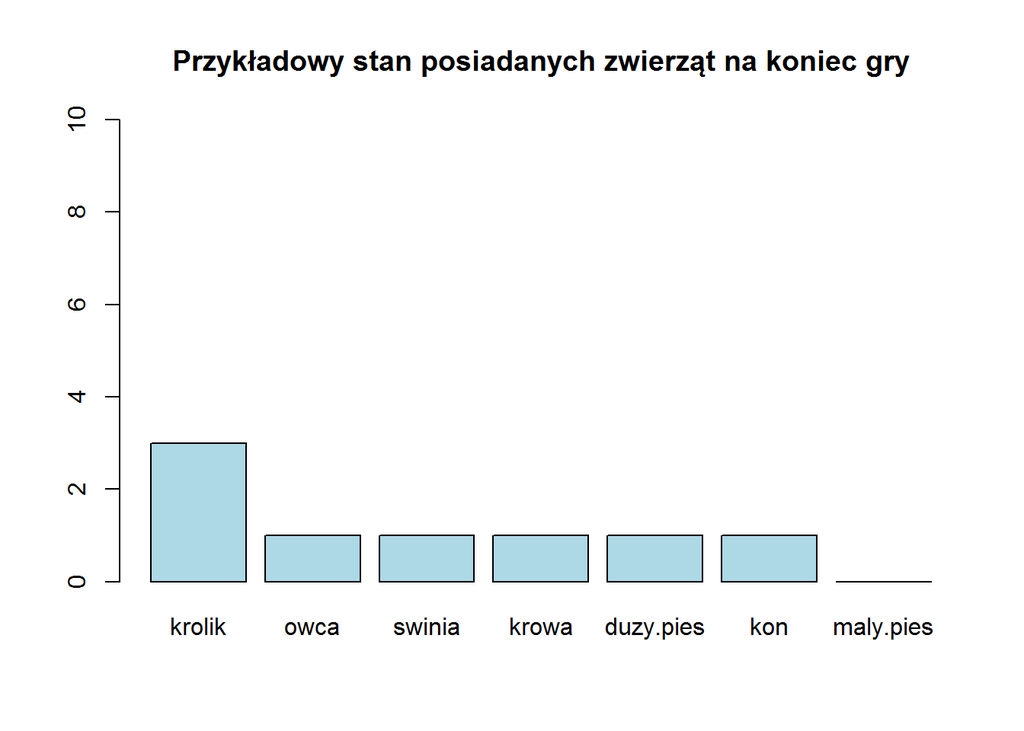

```r
n<-10000                        #liczba symulacji
czasy<-vector("integer",n)         #tu zapisywana jest długość każdej gry

for(l in 1:n){                     #powtarzaj symulację n razy


# definiowanie tabeli "zwierzeta"

zwierzeta<-data.frame(krolik=c(0,1,60),owca=c(0,6,24),swinia=c(0,12,20),krowa=c(0,36,12),duzy.pies=c(0,36,2),kon=c(0,72,6),maly.pies=c(0,6,4),row.names=c("liczba","krolikowarosc","wstadzie"))


# rozpoczęcie gry, graj dopóki nie masz wszystkich wymaganych zwierząt

while (prod(zwierzeta[1,c(-5,-7)])==0){

czasy[l]<-czasy[l]+1                               #licznik rund



#symulacja rzutu kostkami

nakostkach<-c(0,0,0,0,0,0,0,0,0)     #ósme miejsce w wektorze - wilk, dziewiąte - lis

zielona.kostka<-sample(1:9, 1, prob=c(0.5 , 0.25, 1/12 , 1/12, 0, 0,0, 1/12,0))
czerwona.kostka<-sample(1:9, 1, prob=c(0.5 , 1/6, 1/6 , 0, 0, 1/12, 0,0, 1/12))

nakostkach[zielona.kostka]=nakostkach[zielona.kostka]+1
nakostkach[czerwona.kostka]=nakostkach[czerwona.kostka]+1


# dodawanie zwierząt

for (i in c(1:4,6)){

  if( nakostkach[i] != 0){

    a <- min( zwierzeta[3,i]  , floor((zwierzeta[1,i]+nakostkach[i])/2) )

    zwierzeta[3,i]= zwierzeta[3,i] - a
    zwierzeta[1,i]= zwierzeta[1,i] + a

  }
}

# przyjście lisa

if(nakostkach[9]==1){
  if(zwierzeta[1,7] != 0){

    zwierzeta[3,7]= zwierzeta[3,7]+1
    zwierzeta[1,7]= zwierzeta[1,7]-1

  } else {
    zwierzeta[3,1]= zwierzeta[1,1]+zwierzeta[3,1]
    zwierzeta[1,1]=0
    }
}



# przyjście wilka

if(nakostkach[8]==1){
  if(zwierzeta[1,5] != 0){

    zwierzeta[3,5]= zwierzeta[3,5]+1
    zwierzeta[1,5]= zwierzeta[1,5]-1

  } else {

    for(j in 1:4){
      zwierzeta[3,j]= zwierzeta[3,j]+zwierzeta[1,j]
      zwierzeta[1,j]= 0
    }

  }
}


# wymiana na tańsze zwierzęta - kończąca grę

for (i in 6:2){
  if (zwierzeta[1,i]>1){

    if (prod(zwierzeta[1,i:6])>0){
      zwierzeta[1,i]<-zwierzeta[1,i]-1
      zwierzeta[3,i]<-zwierzeta[3,i]+1
      for (j in (i-1):1){
        zwierzeta[1,j]<-zwierzeta[1,j]+1
        zwierzeta[3,j]<-zwierzeta[3,j]-1
      }

    }
  }
}


# wymiana na droższe zwierzęta

for (i in 6:2){

  if (zwierzeta[1,i]==0){         #sprawdzam, czy nie mam i-tego zwierzęcia
    if((sum(zwierzeta[1,1:(i-1)]*zwierzeta[2,1:(i-1)]))>=zwierzeta[2,i]){
      zwierzeta[1,i]<-1
      zwierzeta[3,i]<-zwierzeta[3,i]-1
      dosplaty<-zwierzeta[2,i]
      j<-(i-1)
      while(dosplaty>0){
        if (zwierzeta[1,j]>=1){              #sprzedaję zwierzęta kolejno od największych
          dosplaty<-(dosplaty-zwierzeta[2,j])
          zwierzeta[1,j]<-zwierzeta[1,j]-1
          zwierzeta[3,j]<-zwierzeta[3,j]+1
        }
        if (zwierzeta[1,j]==0){
          j<-(j-1)
        }
      }
      break
    }
  }
}
}
}


barplot(as.matrix(zwierzeta)[1,],ylim=c(0,10),col="lightblue", main="Przykładowy stan posiadanych zwierząt na koniec gry")
```

## Rozkład czasu gry

```r
summary(czasy)
```

```
##    Min. 1st Qu.  Median    Mean 3rd Qu.    Max.
##   11.00   41.00   61.00   72.87   92.00  481.00
```

```r
sd(czasy)
```

```
## [1] 45.52647
```

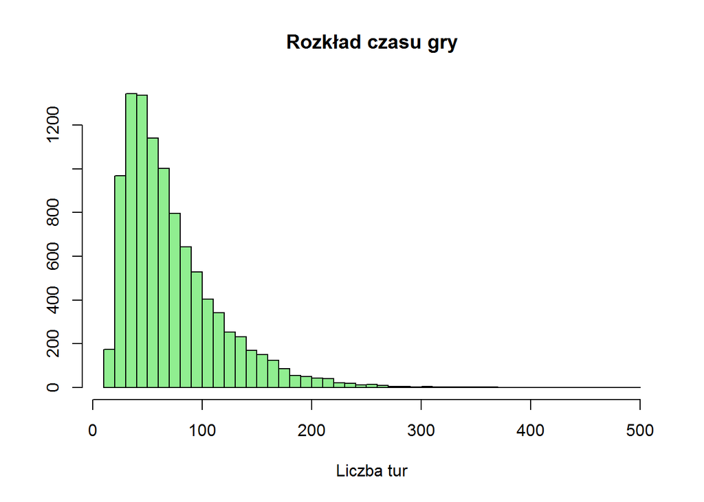

```r
hist(czasy,breaks=(10*1:50),main="Rozkład czasu gry", col="lightgreen",xlab="Liczba tur",ylab=NULL)
```